# European Working Hours Example

Looking at the development between 1996 and 2006

Connor Guest

6/5/2019

[output not shown]

## 0.1 Summary

The **International Labour Organization (ILO)** has many [data sets](http://www.ilo.org/global/statistics-and-databases/lang--en/index.htm) on working conditions. For example, one can look at how weekly working hours have been decreasing in many countries of the world, while monetary compensation has risen. In this report, *the reduction in weekly working hours* in European countries is analysed, and a comparison between 1996 and 2006 is made. All analysed countries have seen a decrease in weekly working hours since 1996 – some more than others.

## 0.2 Preparations

```r
library(dplyr)
library(ggplot2)
library(forcats)
```

## 0.3 Analysis

### 0.3.1 Data

The herein used data can be found in the statistics database of the ILO. For the purpose of this course, it has been slightly preprocessed.

```r
load(url("http://s3.amazonaws.com/assets.datacamp.com/production/course_5807/datasets/ilo_data.RData"))
```

The loaded data contains

| n |
| --- |
| 380 |

rows.

```r
# Some summary statistics
ilo_data %>%
  group_by(year) %>%
  summarize(mean_hourly_compensation = mean(hourly_compensation),
            mean_working_hours = mean(working_hours))
```

| year | mean_hourly_compensation | mean_working_hours |
| --- | --- | --- |
| 1980 | 9.267500 | 33.98103 |
| 1981 | 8.692500 | 33.61923 |
| 1982 | 8.355000 | 33.47409 |
| 1983 | 7.809091 | 33.86589 |
| 1984 | 7.543636 | 33.71051 |
| 1985 | 7.786364 | 33.73358 |
| 1986 | 9.700000 | 33.97494 |
| 1987 | 12.146923 | 33.58138 |
| 1988 | 13.199231 | 33.66441 |
| 1989 | 13.136154 | 33.53312 |
| 1990 | 16.016923 | 33.41275 |
| 1991 | 16.548461 | 33.04459 |
| 1992 | 17.807692 | 32.82919 |
| 1993 | 16.502857 | 32.48288 |
| 1994 | 16.543333 | 32.92779 |
| 1995 | 18.420589 | 33.25749 |
| 1996 | 18.528824 | 33.15975 |
| 1997 | 16.910000 | 33.10471 |
| 1998 | 16.999412 | 32.94524 |
| 1999 | 16.865882 | 32.75325 |
| 2000 | 15.390000 | 32.45301 |
| 2001 | 15.495882 | 32.10170 |
| 2002 | 17.186471 | 31.89615 |
| 2003 | 20.969412 | 31.77210 |
| 2004 | 23.687059 | 31.82506 |
| 2005 | 24.501176 | 31.82508 |
| 2006 | 25.446470 | 31.78460 |

As can be seen from the above table, the average weekly working hours of European countries have been descreasing since 1980.

### 0.3.2 Preprocessing

The data is now filtered so it only contains the years 1996 and 2006 – a good time range for comparison.

```r
ilo_data <- ilo_data %>%
  filter(year == "1996" | year == "2006")

# Reorder country factor levels
ilo_data <- ilo_data %>%
  # Arrange data frame first, so last is always 2006
  arrange(year) %>%
  # Use the fct_reorder function inside mutate to reorder countries by working hours in 2006
  mutate(country = fct_reorder(country,
                               working_hours,
                               last))
```

### 0.3.3 Results

In the following, a plot that shows the reduction of weekly working hours from 1996 to 2006 in each country is produced.

```r
# Compute temporary data set for optimal label placement
median_working_hours <- ilo_data %>%
  group_by(country) %>%
  summarize(median_working_hours_per_country = median(working_hours)) %>%
  ungroup()

# Have a look at the structure of this data set
str(median_working_hours)
```

```
## Classes 'tbl_df', 'tbl' and 'data.frame':    17 obs. of  2 variables:
##  $ country                         : Factor w/ 30 levels "Netherlands",..: 1 2 3 4 5 6 7 8 9 10 ...
##  $ median_working_hours_per_country: num  27 27.8 28.4 31 30.9 ...
```

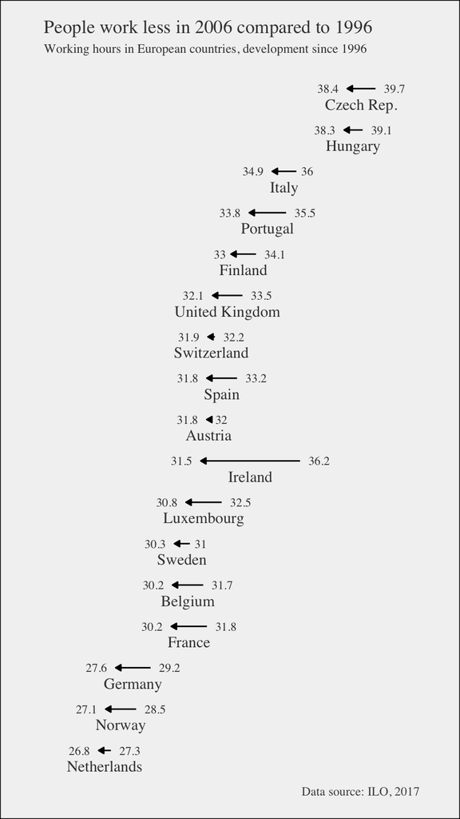

```r
# Plot
ggplot(ilo_data) +
  geom_path(aes(x = working_hours, y = country),
            arrow = arrow(length = unit(1.5, "mm"), type = "closed")) +
  # Add labels for values (both 1996 and 2006)
  geom_text(
        aes(x = working_hours,
            y = country,
            label = round(working_hours, 1),
            hjust = ifelse(year == "2006", 1.4, -0.4)
          ),
        # Change the appearance of the text
        size = 3,
        family = "serif",
        color = "gray25"
   ) +
  # Add labels for country
  geom_text(data = median_working_hours,
            aes(y = country,
                x = median_working_hours_per_country,
                label = country),
            vjust = 2,
            family = "serif",
            color = "gray25") +
  # Add titles
  labs(
    title = "People work less in 2006 compared to 1996",
    subtitle = "Working hours in European countries, development since 1996",
    caption = "Data source: ILO, 2017"
  ) +
  # Apply your theme
  theme_ilo() +
  # Remove axes and grids
  theme(
    axis.ticks = element_blank(),
    axis.title = element_blank(),
    axis.text = element_blank(),
    panel.grid = element_blank(),
    # Also, let's reduce the font size of the subtitle
    plot.subtitle = element_text(size = 9)
  ) +
  # Reset coordinate system
  coord_cartesian(xlim = c(25, 41))
```

#### 0.3.3.1 An interesting correlation

The results of another analysis are shown here, even though they cannot be reproduced with the data at hand.

[figure not shown]

The relationship between weekly working hours and hourly compensation.

As you can see, there’s also an interesting relationship. The more people work, the less compensation they seem to receive, which seems kind of unfair. This is quite possibly related to other proxy variables like overall economic stability and performance of a country.